# CFRM 500 Final Project

# Construction of Cointegrated Mean-Reverting Portfolios and Backtesting

### *Weining Xu (xwnx10)*

## Department of Applied Mathematics, University of Washington

# 1. Introduction

Retail companies specialize in the sale of goods or services to consumers. Products sold by retailers include apparel, jewelry, house wares, small appliances, electronics, groceries, pharmaceutical products, as well as a broad range of services such as tool and equipment rentals. Retail sales volume is part of consumer spending, which accounts for about two-thirds of U.S. economic activity.

Since there is a strong correlation between retail industry and macroeconomics historically, we can clearly see there is some long-term co-movements of the stock prices of retailers. These co-movements motivate us to investigate the cointegration series of these retailer stocks, and hopefully implement a mean-reversion trading strategy.

In this project, in terms of equity selection, we focus on two sporting good retailers: Dick's Sporting Goods (**DKS**), Hibbett Sports (**HIBB**), and two lifestyle related retailers: Urban Outfitters (**URBN**), and Kohl's (**KSS**). We will construct a cointegrated portfolio with these 4 stocks, by applying the standard Johansen test. Then we will implement a mean-reversion trading strategy and backtest the performance of this strategy.

# 2. Portfolio Construction

First, we import some necessary libraries.

```python
import matplotlib.pyplot as plt
import seaborn as sns
%matplotlib inline
%config InlineBackend.figure_format = 'retina'

import numpy as np
import pandas as pd
import yfinance as yf
import statsmodels.tsa.stattools as ts
```

As we mentioned before, we will use the standard Johansen test for constructing the conintegrated portfolio. Here, we use the code from python library johansen.

```python
MAX_EVAL_0 = """2.98    4.13    6.94
                9.47    11.22   15.09
                15.72   17.80   22.25
                21.84   24.16   29.06
                27.92   30.44   35.72
                33.93   36.63   42.23
                39.91   42.77   48.66
                45.89   48.88   55.04
                51.85   54.97   61.35
                57.80   61.03   67.65
                63.73   67.08   73.89
                69.65   73.09   80.12"""

TRACE_0 = """2.98  4.13    6.94
             10.47   12.32   16.36
             21.78   24.28   29.51
             37.03   40.17   46.57
             56.28   60.06   67.64
             79.53   83.94   92.71
             106.74  111.78  121.74
             138.00  143.67  154.80
             173.23  179.52  191.83
             212.47  219.41  232.84
             255.68  263.26  278.00
             302.90  311.13  326.96"""

MAX_EVAL_1 = """7.56    9.16    12.76
                13.91   15.89   20.16
                20.05   22.30   27.07
                26.12   28.59   33.73
                32.17   34.81   40.29
                38.16   40.96   46.75
                44.13   47.07   53.12
                50.11   53.19   59.51
                56.05   59.24   65.79
                61.99   65.30   72.10
                67.93   71.33   78.29
                73.85   77.38   84.51"""

TRACE_1 = """7.56   9.16    12.76
             17.98   20.26   25.08
             32.27   35.19   41.20
             50.53   54.08   61.27
             72.77   76.97   85.34
             99.02   103.84  113.42
             129.23  134.68  145.40
             163.50  169.61  181.51
             201.69  208.45  221.45
             243.96  251.27  265.53
             290.17  298.17  313.75
             340.38  348.99  365.64"""

MAX_EVAL_2 = """2.71    3.84    6.63
                12.30   14.26   18.52
                18.89   21.13   25.86
                25.12   27.58   32.71
                31.24   33.88   39.37
                37.28   40.08   45.87
                43.23   46.23   52.31
                49.29   52.36   58.67
                55.24   58.43   64.99
                61.20   64.51   71.26
                67.13   70.53   77.49
                73.06   76.58   83.70"""

TRACE_2 = """2.71   3.84    6.63
             13.43   15.50   19.94
             27.07   29.80   35.46
             44.49   47.86   54.68
             65.82   69.82   77.82
             91.11   95.75   104.96
             120.37  125.61  135.97
             153.63  159.53  171.09
             190.88  197.37  210.06
             232.11  239.25  253.24
             277.38  285.14  300.29
             326.53  334.98  351.25"""

MAX_EVAL_3 = """10.67   12.52   16.55
                17.23   19.39   23.97
                23.44   25.82   30.83
                29.54   32.12   37.49
                35.58   38.33   44.02
                41.60   44.50   50.47
                47.56   50.59   56.85
                53.55   56.71   63.17
                59.49   62.75   69.44
                65.44   68.81   75.69
                71.36   74.84   81.94
                77.30   80.87   88.11"""

TRACE_3 = """10.67  12.52   16.55
             23.34   25.87   31.16
             39.75   42.91   49.36
             60.09   63.88   71.47
             84.38   88.80   97.60
             112.65  117.71  127.71
             144.87  150.56  161.72
             181.16  187.47  199.81
             221.36  228.31  241.74
             265.63  273.19  287.87
             313.86  322.06  337.97
             366.11  374.91  392.01"""

MAX_EVAL_4 = """2.71    3.84    6.63
                15.00   17.15   21.74
                21.87   24.25   29.26
                28.24   30.82   36.19
                34.42   37.16   42.86
                40.53   43.42   49.41
                46.56   49.58   55.81
                52.58   55.73   62.17
                58.53   61.81   68.50
                64.53   67.90   74.74
                70.46   73.94   81.07
                76.41   79.97   87.23"""

TRACE_4 = """2.71   3.84    6.63
             16.16   18.40   23.15
             32.06   35.01   41.08
             51.65   55.24   62.52
             75.10   79.34   87.78
             102.47  107.34  116.99
             133.79  139.28  150.08
             169.07  175.16  187.20
             208.36  215.12  228.23
             251.63  259.02  273.37
             298.89  306.90  322.41
             350.12  358.72  375.30"""

mapping = {
    "MAX_EVAL_0": MAX_EVAL_0,
    "TRACE_0": TRACE_0,
    "MAX_EVAL_1": MAX_EVAL_1,
    "TRACE_1": TRACE_1,
    "MAX_EVAL_2": MAX_EVAL_2,
    "TRACE_2": TRACE_2,
    "MAX_EVAL_3": MAX_EVAL_3,
    "TRACE_3": TRACE_3,
    "MAX_EVAL_4": MAX_EVAL_4,
    "TRACE_4": TRACE_4
}
```

```python
from statsmodels.tsa.tsatools import lagmat

class Johansen(object):
    """Implementation of the Johansen test for cointegration.
    References:
        - Hamilton, J. D. (1994) 'Time Series Analysis', Princeton Univ. Press.
        - MacKinnon, Haug, Michelis (1996) 'Numerical distribution functions of
        likelihood ratio tests for cointegration', Queen's University Institute
        for Economic Research Discussion paper.
    """

    def __init__(self, x, model, k=1, trace=True,  significance_level=1):
        """
        :param x: (nobs, m) array of time series. nobs is the number of
        observations, or time stamps, and m is the number of series.
        :param k: The number of lags to use when regressing on the first
        difference of x.
        :param trace: Whether to use the trace or max eigenvalue statistic for
        the hypothesis testing. If False the latter is used.
        :param model: Which of the five cases in Osterwald-Lenum 1992 (or
        MacKinnon 1996) to use.
            - If set to 0, case 0 will be used. This case should be used if
            the input time series have no deterministic terms and all the
            cointegrating relations are expected to have 0 mean.
            - If set to 1, case 1* will be used. This case should be used if
            the input time series has neither a quadratic nor linear trend,
            but may have a constant term, and additionally if the cointegrating
            relations may have nonzero means.
            - If set to 2, case 1 will be used. This case should be used if
            the input time series have linear trends but the cointegrating
            relations are not expected to have linear trends.
            - If set to 3, case 2* will be used. This case should be used if
            the input time series do not have quadratic trends, but they and
            the cointegrating relations may have linear trends.
            - If set to 4, case 2 will be used. This case should be used if
            the input time series have quadratic trends, but the cointegrating
            relations are expected to only have linear trends.
        :param significance_level: Which significance level to use. If set to
        0, 90% significance will be used. If set to 1, 95% will be used. If set
        to 2, 99% will be used.
        """

        self.x = x
        self.k = k
        self.trace = trace
        self.model = model
        self.significance_level = significance_level

        if trace:
            key = "TRACE_{}".format(model)
        else:
            key = "MAX_EVAL_{}".format(model)

        critical_values_str = mapping[key]

        select_critical_values = np.array(
            critical_values_str.split(),
            float).reshape(-1, 3)

        self.critical_values = select_critical_values[:, significance_level]

    def mle(self):
        """Obtain the cointegrating vectors and corresponding eigenvalues.
        Maximum likelihood estimation and reduced rank regression are used to
        obtain the cointegrating vectors and corresponding eigenvalues, as
        outlined in Hamilton 1994.
        :return: The possible cointegrating vectors, i.e. the eigenvectors
        resulting from maximum likelihood estimation and reduced rank
        regression, and the corresponding eigenvalues.
        """

        # Regressions on diffs and levels of x. Get regression residuals.

        # First differences of x.
        x_diff = np.diff(self.x, axis=0)

        # Lags of x_diff.
        x_diff_lags = lagmat(x_diff, self.k, trim='both')

        # First lag of x.
        x_lag = lagmat(self.x, 1, trim='both')

        # Trim x_diff and x_lag so they line up with x_diff_lags.
        x_diff = x_diff[self.k:]
        x_lag = x_lag[self.k:]

        # Include intercept in the regressions if self.model != 0.
        if self.model != 0:
            ones = np.ones((x_diff_lags.shape[0], 1))
            x_diff_lags = np.append(x_diff_lags, ones, axis=1)

        # Include time trend in the regression if self.model = 3 or 4.
        if self.model in (3, 4):
            times = np.asarray(range(x_diff_lags.shape[0])).reshape((-1, 1))
            x_diff_lags = np.append(x_diff_lags, times, axis=1)

        # Residuals of the regressions of x_diff and x_lag on x_diff_lags.
        try:
            inverse = np.linalg.pinv(x_diff_lags)
        except:
            print("Unable to take inverse of x_diff_lags.")
            return None

        u = x_diff - np.dot(x_diff_lags, np.dot(inverse, x_diff))
        v = x_lag - np.dot(x_diff_lags, np.dot(inverse, x_lag))

        # Covariance matrices of the residuals.
        t = x_diff_lags.shape[0]
        Svv = np.dot(v.T, v) / t
        Suu = np.dot(u.T, u) / t
        Suv = np.dot(u.T, v) / t
        Svu = Suv.T

        try:
            Svv_inv = np.linalg.inv(Svv)
        except:
            print("Unable to take inverse of Svv.")
            return None
        try:
            Suu_inv = np.linalg.inv(Suu)
        except:
            print("Unable to take inverse of Suu.")
            return None

        # Eigenvalues and eigenvectors of the product of covariances.
        cov_prod = np.dot(Svv_inv, np.dot(Svu, np.dot(Suu_inv, Suv)))
        eigenvalues, eigenvectors = np.linalg.eig(cov_prod)

        # Normalize the eigenvectors using Cholesky decomposition.
        evec_Svv_evec = np.dot(eigenvectors.T, np.dot(Svv, eigenvectors))
        cholesky_factor = np.linalg.cholesky(evec_Svv_evec)
        try:
            eigenvectors = np.dot(eigenvectors,
                                  np.linalg.inv(cholesky_factor.T))
        except:
            print("Unable to take the inverse of the Cholesky factor.")
            return None

        # Ordering the eigenvalues and eigenvectors from largest to smallest.
        indices_ordered = np.argsort(eigenvalues)
        indices_ordered = np.flipud(indices_ordered)
        eigenvalues = eigenvalues[indices_ordered]
        eigenvectors = eigenvectors[:, indices_ordered]

        return eigenvectors, eigenvalues

    def h_test(self, eigenvalues, r):
        """Carry out hypothesis test.
        The null hypothesis is that there are at most r cointegrating vectors.
        The alternative hypothesis is that there are at most m cointegrating
        vectors, where m is the number of input time series.
        :param eigenvalues: The list of eigenvalues returned from the mle
        function.
        :param r: The number of cointegrating vectors to use in the null
        hypothesis.
        :return: True if the null hypothesis is rejected, False otherwise.
        """

        nobs, m = self.x.shape
        t = nobs - self.k - 1

        if self.trace:
            m = len(eigenvalues)
            statistic = -t * np.sum(np.log(np.ones(m) - eigenvalues)[r:])
        else:
            statistic = -t * np.sum(np.log(1 - eigenvalues[r]))

        critical_value = self.critical_values[m - r - 1]

        if statistic > critical_value:
            return True
        else:
            return False

    def johansen(self):
        """Obtain the possible cointegrating relations and numbers of them.
        See the documentation for methods mle and h_test.
        :return: The possible cointegrating relations, i.e. the eigenvectors
        obtained from maximum likelihood estimation, and the numbers of
        cointegrating relations for which the null hypothesis is rejected.
        """

        nobs, m = self.x.shape

        try:
            eigenvectors, eigenvalues = self.mle()
        except:
            print("Unable to obtain possible cointegrating relations.")
            return None

        rejected_r_values = []
        for r in range(m):
            if self.h_test(eigenvalues, r):
                rejected_r_values.append(r)

        return eigenvectors, rejected_r_values
```

Now, the johansen test function is handy to use.

We then download the stocks' historic prices from yahoo finance, from 01/01/2010 to 12/15/2020.

```python
data = yf.download('DKS HIBB URBN KSS', start='2010-01-01', end='2020-12-15')
prices = data.iloc[:,:4]
```

```
[*********************100%***********************]  4 of 4 completed
```

```python
prices
```

| Date | Adj Close DKS | Adj Close HIBB | Adj Close KSS | Adj Close URBN |
| --- | --- | --- | --- | --- |
| 2009-12-31 | 20.682598 | 21.990000 | 37.402615 | 34.990002 |
| 2010-01-04 | 20.790705 | 22.309999 | 37.437294 | 34.910000 |
| 2010-01-05 | 21.048515 | 22.580000 | 37.465042 | 35.560001 |
| 2010-01-06 | 20.840605 | 23.100000 | 37.950508 | 35.279999 |
| 2010-01-07 | 21.663921 | 23.480000 | 37.076653 | 34.080002 |
| ... | ... | ... | ... | ... |
| 2020-12-08 | 55.797398 | 48.730000 | 40.090000 | 27.250000 |
| 2020-12-09 | 54.137001 | 46.410000 | 39.669998 | 27.260000 |
| 2020-12-10 | 54.590000 | 45.750000 | 39.320000 | 27.190001 |
| 2020-12-11 | 53.549999 | 46.139999 | 38.240002 | 26.639999 |
| 2020-12-14 | 52.860001 | 43.790001 | 36.919998 | 26.080000 |

2758 rows × 4 columns

We plot the historic stock value of the 4 stocks, and indeed there are some long-term co-movements.

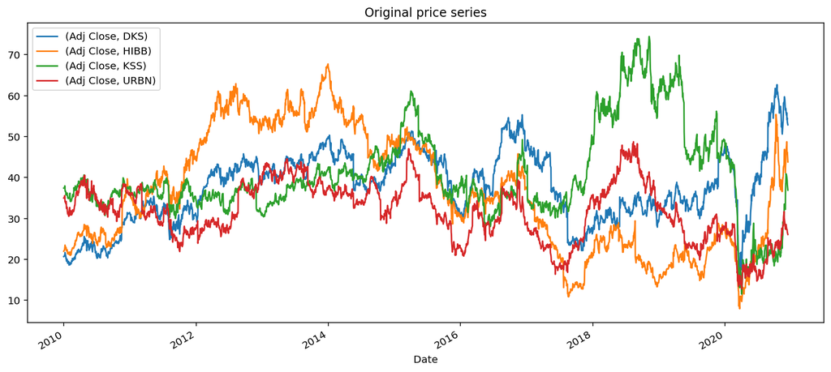

```python
# Plot of original price series.
prices.plot(title="Original price series", legend=None, figsize=(14, 6))
plt.legend()
```

Now we apply the Johansen test to the stock prices up until 01/01/2018 to find the coefficients that make up the cointegrated portfolio.

```python
x = prices[:'2018/01/01']
x_centered = x - x.mean()

johansen = Johansen(x_centered, model=2, significance_level=2)
eigenvectors, r = johansen.johansen()

vec = eigenvectors[:, 0]
vec_min = np.min(np.abs(vec))
vec = vec / vec_min

print(f'The first cointegrating relation: {vec}')
```

```
The first cointegrating relation: [ 1.07140872 -1.         -1.21211074  2.80054441]
```

By applying the test, we have the following portfolio,

$$ P_t = 1.07140872\ \text{DKS}_t - \text{HIBB}_t-1.21211074\ \text{KSS}_t + 2.80054441\ \text{URBN}_t $$

We now plot the cointegrated portfolio value over time, including the time period after 01/01/2018.

```
44.03376884071871 13.390110588785344
```

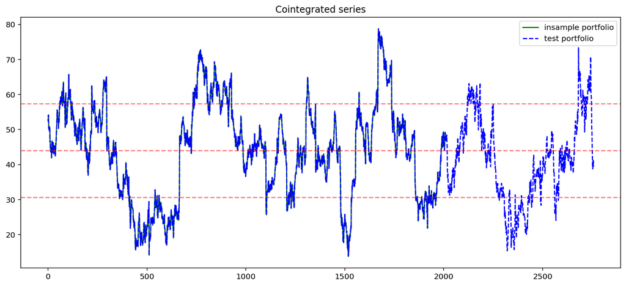

```python
plt.title("Cointegrated series")

# In-sample plot.
portfolio_insample = np.dot(x, vec)
plt.plot(portfolio_insample, 'g-', label='insample portfolio')

# Test plot.
x_test = prices
portfolio_test = np.dot(x_test, vec)
plt.plot(portfolio_test, 'b--', label='test portfolio')
plt.legend()
plt.gcf().set_size_inches(14, 6)

# In sample mean and std.
in_sample = np.dot(x, vec)
mean = np.mean(in_sample)
std = np.std(in_sample)
print(np.mean(in_sample), np.std(in_sample))

# Plot the mean and one std above and below it.
plt.axhline(y = mean - std, color='r', ls='--', alpha=.5)
plt.axhline(y = mean, color='r', ls='--', alpha=.5)
plt.axhline(y = mean + std, color='r', ls='--', alpha=.5)
```

The cointegrated series seems to be mean-reverting, we now double check with the ADF test.

```python
ts.adfuller(portfolio_test)
```

```
(-4.107675749419737,
 0.0009406136890007102,
 1,
 2756,
 {'1%': -3.4327249641397053,
  '5%': -2.862589289388965,
  '10%': -2.567328570112761},
 11831.561548427297)
```

# 3. Strategy Implementation

To implement the strategy for backtesting, we create a `position` column in the dataframe, where '1' means long/exit short of the portfolio, and '-1' means short/exit long of the portfolio. We first start with the trading threshold of $\pm1\sigma$, meaning we enter the long/exit the short position when the portfolio value falls below mean minus one times the standard deviation, and enter short/exit long position when the portfolio value rises above mean plus one times the standard deviation.

```python
threshold = 1*std
prices['distance'] = portfolio_test - mean

prices['position'] = np.where(prices['distance'] > threshold, -1, np.nan)

prices['position'] = np.where(prices['distance'] < -threshold, 1, prices['position'])

prices['position'] = prices['position'].ffill().fillna(0)
```

We plot our positions over time with the portfolio series in the back.

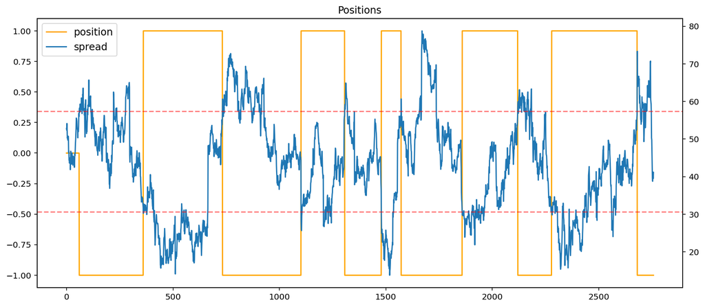

```python
plt.title('Positions')
ln1 = plt.plot(prices['position'].to_numpy(), color='orange', label='position')
ax2 = plt.gca().twinx()
ln2 = ax2.plot(portfolio_test, label='spread')
plt.axhline(y = mean - std, color='r', ls='--', alpha=.5)
plt.axhline(y = mean + std, color='r', ls='--', alpha=.5)
plt.gcf().set_size_inches(14, 6)

lns = ln1+ln2
labs = [l.get_label() for l in lns]
plt.legend(lns, labs, fontsize=12)
```

# 4. Backtesting

We now backtest our strategy performance over the last 10 years.

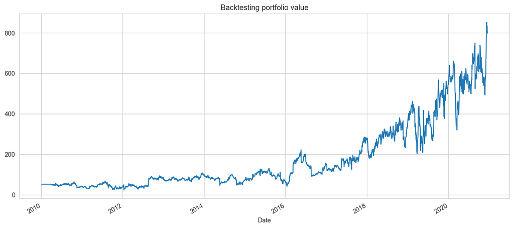

```python
prices['returns'] = pd.Series(portfolio_test).pct_change().to_numpy()
prices['portfolio'] = np.cumprod(1+prices['position']*(prices['returns']))*portfolio_test[0]

sns.set_style('whitegrid')
plt.title('Backtesting portfolio value')
prices.portfolio.plot(figsize=(14, 6))
```

The strategy has a nice return over the last 10 years, we now investigate the drawdown of this strategy.

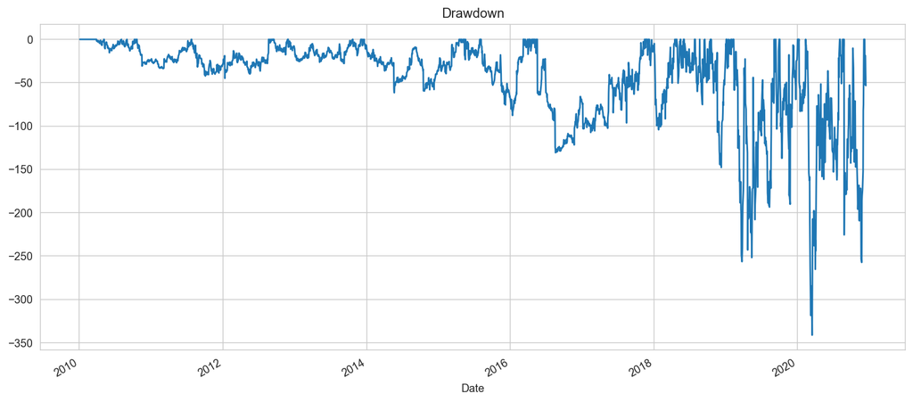

```python
drawdown = []
for i in range(len(prices)):
    drawdown.append(prices.portfolio[i]-np.max(prices.portfolio[:i+1]))

prices['drawdown'] = drawdown
plt.title('Drawdown')
prices['drawdown'].plot(figsize=(14, 6))
```

From the plot we can see that this strategy is not very good in terms of controlling drawdowns. Especially in recent years, when the retailers' stock prices fluctuate with higher volatility, the drawdown of this strategy increases.

# 5. Conclusion

In this project, we have investigated the cointegration among the prices of four stocks in the retail industry: **DKS**, **HIBB**, **KSS**, and **URBN**, construted a stationary and tradable portfolio using Johansen test. We then implemented a mean-reverting trading strategy and backtested the performance of the strategy over the last 10 years. The strategy is overall profitable, although has some larger drawdowns in recent years due to market volatility.

Retail industry is only one of the important sectors in the economics, and there are many other industries, where the stock prices of those also have some kind of co-movements. Therefore, one may utilize machine learning techiniques to automatically select a sector in the market to trade to maximize the performance. Also, mean-reverting trading strategy is only one of the most intuitive quantitative trading strategies, there are lot more other strategies out there.

# References

Leung, T. and Nguyen, H. (2019). Constructing Cointegrated Cryptocurrency Portfolios for Statistical Arbitrage. *Studies in Economics and Finance*, 36(3):581-599.

Johansen Python Library. Available at https://github.com/iisayoo/johansen